[O’Hara on GitHub](https://github.com/oharac)

# Gather stressors and process to analysis CRS

Compiled on Fri Sep 15 16:49:27 2023 by ohara

```r
knitr::opts_chunk$set(echo = TRUE, message = FALSE, warning = FALSE)

library(terra)
library(sf)
library(tidyverse)
library(here)

source(here('common_fxns.R'))
source('stressor_fxns.R') ### must be in same directory for relative path
```

# 1 Summary

Gather stressor layers and process to the CRS for this analysis: Mollweide, 1 km x 1 km. Identify gapfill needs if necessary. Layers gathered/processed here:

- Benthic disturbance (from effort in destructive fishing practices)
- Direct human (from human population density)
- Extreme temperature events
- Sea Level Rise
- Ocean Acidification
- Ultraviolet
- Light pollution

Note that for some stressors, we may need to convert a raw value (e.g., ship track count) to an intensity (count per km^2) prior to reprojecting.

Note in methodology: where in CHI at ~1 km Mollweide we frequently use the 99.99%ile as a reference point, here I am using the 99.9%ile (one fewer decimal). Our reference points will be generally pulled from bc waters rather than global.

# 2 Data

All files are located on Mazu, starting from `/home/shares/ohi/` unless otherwise noted.

## 2.1 Benthic disturbance from fishing

- GFW data to estimate benthic disturbance from food systems project:
  - dir: `stressors_2021/_dataprep/fishing_benthic_destructive`
    - file: `FishingWatch_annual_effort_destructive_hours_2017.tif`
    - log-transform
  - cite food systems project where GFW data was processed to this layer?
  - or cite GFW and include methods/code to generate this layer within this project.
  - Information from the food systems project: https://github.com/OHI-Science/food_systems/tree/master/fisheries/marine/disturbance

## 2.2 Direct human impact/habitat destruction

using population as proxy:

- dir: `git-annex/globalprep/mar_prs_population/v2020/int/`
  - file: `human_density_2020_mol_tmp.tif`
  - also files for `human_count...` and `yearly_change...`
  - Log-transform

## 2.3 Organic chemical pollution?

## 2.4 Microplastics

Using data from van Sebille (2015):

- Van Sebille, E., Wilcox, C., Lebreton, L., Maximenko, N., Hardesty, B. D., Van Franeker, J. A., Eriksen, M., Siegel, D., Galgani, F., & Law, K. L. (2015). A global inventory of small floating plastic debris. Environmental Research Letters, 10(12), 124006.
- dir: `stressors/microplastics`
  - file: `vansebille_mass.csv`

## 2.5 Climate stressors other than SST

Count these as intensities - no conversion to intensity required.

### 2.5.1 Extreme temperature events

These maps were created for Mel’s MARISCO stressors project. See there for methodology. Nutshell:

1. For each week and raster cell: determine the anomaly value (observed weekly temp - climatological weekly mean) that corresponds to the 90th quantile using years ~1985-2015.
2. Then for each week/raster cell: determine the weeks in each year of 2016-2020 that exceed the 90th quantile value calculated using the 1985-2015 data.
3. Sum exceedences occurring from 2016-2020.
- Use annual mean SST anomaly rasters from here:
  - dir: `/stressors_2021/_dataprep/SST_past_present/final_extreme`
    - file: `sst_exceeds_90quant_2016-2020.tif`
  - These are projected to Mollweide, but not rescaled 0-1 (currently, sum of extreme weeks / total number of weeks)
  - Project to bc 1 km resolution
- See this issue for methods, for now: https://github.com/mapping-marine-spp-vuln/issues/issues/22

### 2.5.2 Sea level rise from OHI 2021

- Use annual mean SLR anomaly rasters from here:
  - dir: `git-annex/globalprep/prs_slr/v2021/int/msla_annual_mean/`
    - file: `msla_annual_2019.tif`
  - These are pre-transform and mask. Transformed and masked are also available, but let’s use these so we can make sure the transform and mask are accurate to our particular CRS.
- See OHI processing script for details: `https://github.com/OHI-Science/ohiprep_v2021/blob/gh-pages/globalprep/prs_slr/v2021/slr_layer_prep_v2.Rmd`

### 2.5.3 Ocean acidification from CHI Pace of Change (2017 data year)

- dir: `git-annex/impact_acceleration/stressors/oa/final`
  - file: `oa_2017_rescaled_mol.tif`
- These are in Mollweide but at 934 meter resolution… reproject to 1 km

### 2.5.4 Ultraviolet radiation from OHI 2021

- dir: `git-annex/globalprep/prs_uv/v2021/int/rescaled/`
  - file: `annual_diff_2016_2020_rescaled.tif`
- See OHI processing script for details: `https://ohi-science.org/ohiprep_v2020/globalprep/prs_uv/v2020/uv_dataprep.html`

## 2.6 Light pollution

- Light pollution from [Li et al. (2020) A harmonized global nighttime light dataset 1992–2018](https://www.nature.com/articles/s41597-020-0510-y#Sec8)
  - Night time light averaged over year, at 30 arc-second resolution.
  - Downloaded data from FigShare 11/30/21: https://figshare.com/articles/dataset/Harmonization_of_DMSP_and_VIIRS_nighttime_light_data_from_1992-2018_at_the_global_scale/9828827/2?file=17626049

# 3 Methods

For each stressor layer, reproject to 1 km bc CRS and mask to ocean cells.

```r
here_ohi <- function(f = '', ...) {
  f <- paste(f, ..., sep = '/')
  f <- stringr::str_replace_all(f, '\\/+', '/')
  sprintf('/home/shares/ohi/%s', f)
}

### Load ocean raster in bc CRS and 1 km resolution (analysis CRS and res)
ocean_rast <- rast(here('_spatial/ocean_bc_1km.tif'))

### load ocean area (in km^2) in 0.01 deg WGS84 (for converting values to
### intensities prior to reprojecting) - is this a reasonable resolution?
ocean_a_0.01_f <- here_anx('_spatial/ocean_area_wgs84_0.01deg.tif')

if(!file.exists(ocean_a_0.01_f)) {
  ### Code to create ocean area raster at 0.1 degree:
  base_rast_0.01deg <- rast(ext = ext(c(-180, 180, -90, 90)),
                            res = 0.01, crs = '+init=epsg:4326')
  ocean_mask_sf <- read_sf(here('_spatial/ne_10m_ocean/ne_10m_ocean.shp'))
  ocean_rast_0.01deg <- terra::rasterize(ocean_mask_sf, base_rast_0.01deg)
  ocean_area_0.01deg <- terra::cellSize(ocean_rast_0.01deg) / 1e6 ### in km^2
  ocean_a_0.01_masked <- mask(ocean_area_0.01deg, ocean_rast_0.01deg)
  writeRaster(ocean_a_0.01_masked, ocean_a_0.01_f, overwrite = TRUE)
}

ocean_area_0.01deg <- rast(ocean_a_0.01_f)
# plot(ocean_area_0.01deg, axes = FALSE, main = 'cell area, km^2, 0.01 degree')
```

## 3.1 Global Fishing Watch for benthic disturbance

Reproject, then rescale 0-1.

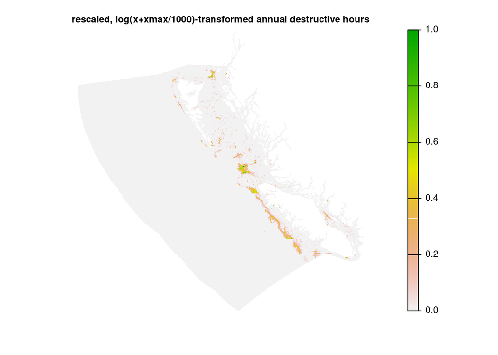

```r
benth_dist_f <- here('_data/stressors_bc/fishing_benthic_dest_2017.tif')
### unlink(benth_dist_f)

if(!file.exists(benth_dist_f)) {
  local_f <- here_anx('stressors/fishing',
                     'FishingWatch_annual_effort_destructive_hours_2017.tif')
  if(!file.exists(local_f)) {
    orig_f <- here_ohi('stressors_2021/_dataprep',
                       'fishing_benthic_destructive',
                       'FishingWatch_annual_effort_destructive_hours_2017.tif')
    file.copy(orig_f, local_f)
  }
  raw_r <- rast(local_f)
  # class       : SpatRaster
  # dimensions  : 18000, 36000, 1  (nrow, ncol, nlyr)
  # resolution  : 0.01, 0.01  (x, y)
  # extent      : -180.005, 179.995, -89.995, 90.005  (xmin, xmax, ymin, ymax)
  # coord. ref. : lon/lat WGS 84 (EPSG:4326)
  # source      : FishingWatch_annual_effort_destructive_hours_2017.tif
  # name        : FishingWatch_annual_effort_destructive_hours_2017
  # min value   :                                             0.000
  # max value   :                                          1540.895
  watson_area_r <- cellSize(raw_r)
  ### Convert to intensity - hours per km^2
  intensity_r <- raw_r / watson_area_r

  ### reproject intensity to Mollweide and clip out tiny neg numbers
  reproj_intens_r <- project(intensity_r, ocean_rast) %>%
    mask(ocean_rast)
  reproj_intens_r[reproj_intens_r < 0] <- 0

  ### rescale the reprojected raster, fill all NAs with 0, then mask to just ocean
  reproj_log_r <- log_plus(reproj_intens_r)
  reproj_log_r <- reproj_log_r %>%
    rescale_stressor()
  values(reproj_log_r)[is.na(values(reproj_log_r))] <- 0

  log_r_ocean <- reproj_log_r %>%
    mask(ocean_rast)

  ### round to drop ludicrous precision then save out
  values(log_r_ocean) <- round(values(log_r_ocean), 5)
  writeRaster(log_r_ocean, benth_dist_f, overwrite = TRUE)

}

r <- rast(benth_dist_f)

plot(r, axes = FALSE,
     main = 'rescaled, log(x+xmax/1000)-transformed annual destructive hours')
```

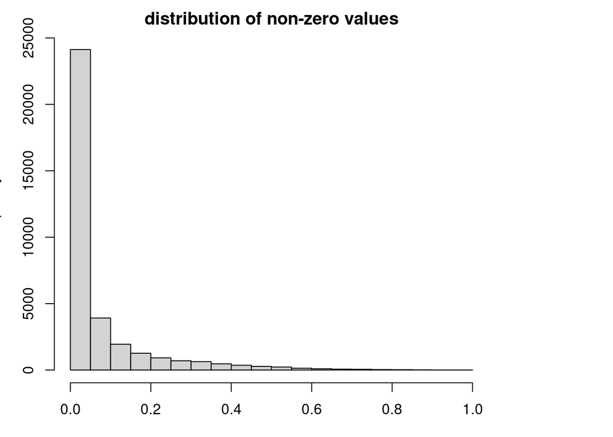

```r
hist(r[r > 0], main = 'distribution of non-zero values')
```

## 3.2 Land-based stressors

### 3.2.1 Direct human impact/habitat destruction using population as proxy

The data for this is population density or count (on land). We want an indication of the number of people living within 25 km (or so) of the coast. To do this, try `raster::focal()`: Calculate focal (“moving window”) values for the neighborhood of focal cells using a matrix of weights, perhaps in combination with a function.

- To get a circular window on the 934 m native resolution of OHI population data, use a matrix with 55 rows and columns. Assign value of 1 for cells within a 27-cell radius of the center.
- Fill all NAs with zeros, then apply `focal()` to sum up the total population within the circular window, and fill the cell with that value.
- Then mask to just coastal cells, which have now been filled with population within 25 km. As the cells edge out from shore, the farther cells will have lower values, and reprojecting to 1 km will be affected by this as it will bring down the average; but since we are rescaling the results from 0 to 1, this should not be a critical concern.

Rescale based on 99.9%ile, with log(x+1) transform (based on Mora, C. et al. (2011). Global Human Footprint on the Linkage between Biodiversity and Ecosystem Functioning in Reef Fishes. PLOS Biology, 9(4), e1000606. https://doi.org/10.1371/journal.pbio.1000606)

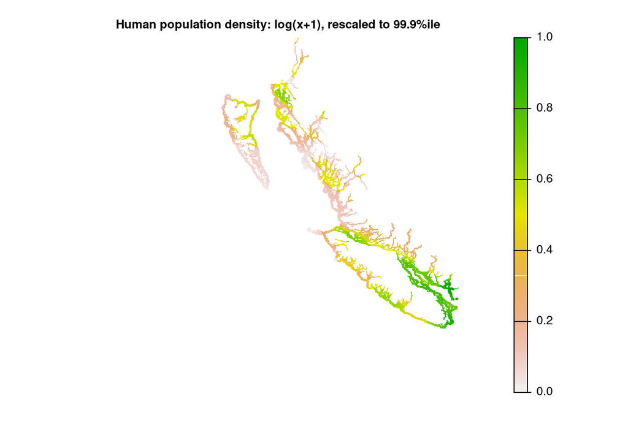

```r
pop_f <- here('_data/stressors_bc/direct_human_2020.tif')
### unlink(pop_f)

if(!file.exists(pop_f)) {
  local_f <- here_anx('stressors/population',
                      'human_density_2020_mol.tif')
  if(file.exists(local_f)) {
    orig_f <- here_ohi('git-annex/globalprep/mar_prs_population/v2020/int/',
                       'human_density_2020_mol.tif')
    file.copy(orig_f, local_f)
  }
  raw_r <- rast(local_f)
  # class       : SpatRaster
  # dimensions  : 19305, 38610, 1  (nrow, ncol, nlyr)
  # resolution  : 934.4789, 934.4789  (x, y)
  # extent      : -18040095, 18040134, -9020047, 9020067  (xmin, xmax, ymin, ymax)
  # coord. ref. : +proj=moll +lon_0=0 +x_0=0 +y_0=0 +datum=WGS84 +units=m +no_defs
  # source      : human_density_2020_mol.tif
  # name        : human_density_2020_mol
  # min value   :                    0.0
  # max value   :               101691.8
  message('Cropping Mollweide pop raster to roughly bc (w/ 50 km buffer)...')
  mol_bc <- create_bc_sf() %>%  ### create wgs84 bc frame
    st_transform(crs(raw_r)) %>%        ### transform to Mollweide
    st_buffer(dist = 50)                ### buffer by 50 km
  pop_r <- crop(raw_r, mol_bc)

  values(pop_r)[is.na(values(pop_r))] <- 0

  focal_pop_f <- here_anx('stressors/population/pop_focal_25km_radius_1km_mol.tif')
  if(!file.exists(focal_pop_f)) {
    message('Summing focal population within 25 km...')
    ### set up focal matrix - weight of 1 within 25 km, 0 outside (remember,
    ### native res is at not quite 1 km...)
    focal_rad <- 27
    focal_dia <- focal_rad*2+1
    focal_mtx <- matrix(nrow = focal_dia, ncol = focal_dia)
    for(i in 1:focal_dia) {
      for(j in 1:focal_dia) {
        ### i <- 1; j <- 1
        r_from_center <- sqrt((i - (focal_rad + 1))^2 + (j - (focal_rad + 1))^2)
        focal_mtx[i, j] <- ifelse(r_from_center < focal_rad, 1, 0)
      }
    }
    ### Calculate focal sum of population (or pop density, for equal area
    ### there is no meaningful difference when rescaling anyway)
    focal_pop_r <- focal(pop_r, w = focal_mtx, fun = sum, na.rm = TRUE)

    message('Writing focal population raster...')
    writeRaster(focal_pop_r, focal_pop_f, overwrite = TRUE)
   }

  focal_pop_r <- rast(focal_pop_f)

  ### in Mollweide, but similar resolution... log transform, then reproject
  log_focal_pop_r <- log(focal_pop_r + 1)

  focal_pop_r_bc <- project(log_focal_pop_r, ocean_rast)

  ### Masking to coastal cells rather than whole ocean, then
  ### rescale based on cropped raster to 99.9%ile
  coastal_r <- rast(here('_spatial/coastal_3nmi_buffer_bc_1km.tif'))
  pop_coastal <- mask(focal_pop_r_bc, coastal_r) %>%
    rescale_stressor(qtile = .999)

  ### round to drop ludicrous precision then save out
  values(pop_coastal) <- round(values(pop_coastal), 5)
  writeRaster(pop_coastal, pop_f)

}

r <- rast(pop_f)

plot(r, axes = FALSE,
     main = 'Human population density: log(x+1), rescaled to 99.9%ile')
```

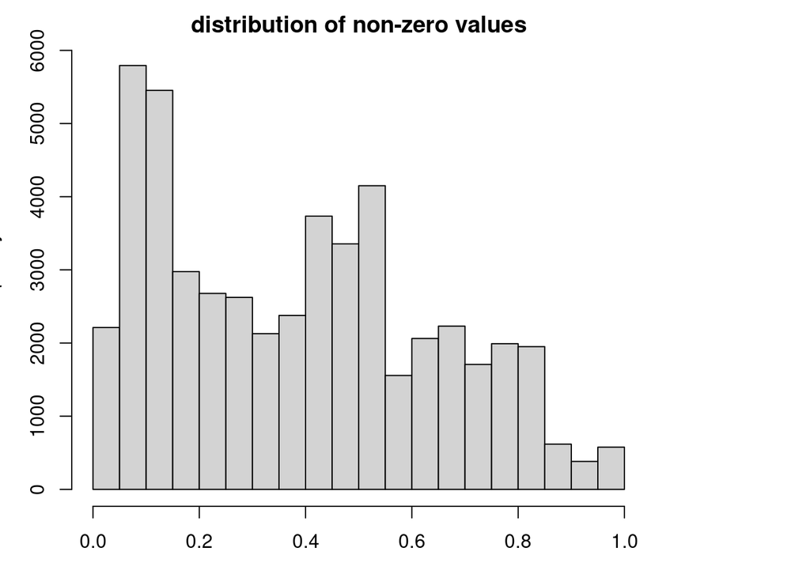

```r
hist(r[r > 0], main = 'distribution of non-zero values')
```

## 3.3 Climate stressors other than long-term temperature rise

### 3.3.1 Sea surface temperature extremes

Analogous to marine heat waves.

- dir: `stressors_2021/_dataprep/SST_past_present/final_extreme` * file: `sst_exceeds_90quant_2016-2020.tif`

```r
x_sst_local_f <- here_anx('stressors/max_temp',
                          'sst_exceeds_90quant_2016-2020.tif')
if(!file.exists(x_sst_local_f)) {
  extreme_sst_orig_f <- here_ohi('stressors_2021/_dataprep/SST_past_present/final_extreme',
                            'sst_exceeds_90quant_2016-2020.tif')
  file.copy(extreme_sst_orig_f, x_sst_local_f)
}
```

```
## [1] TRUE
```

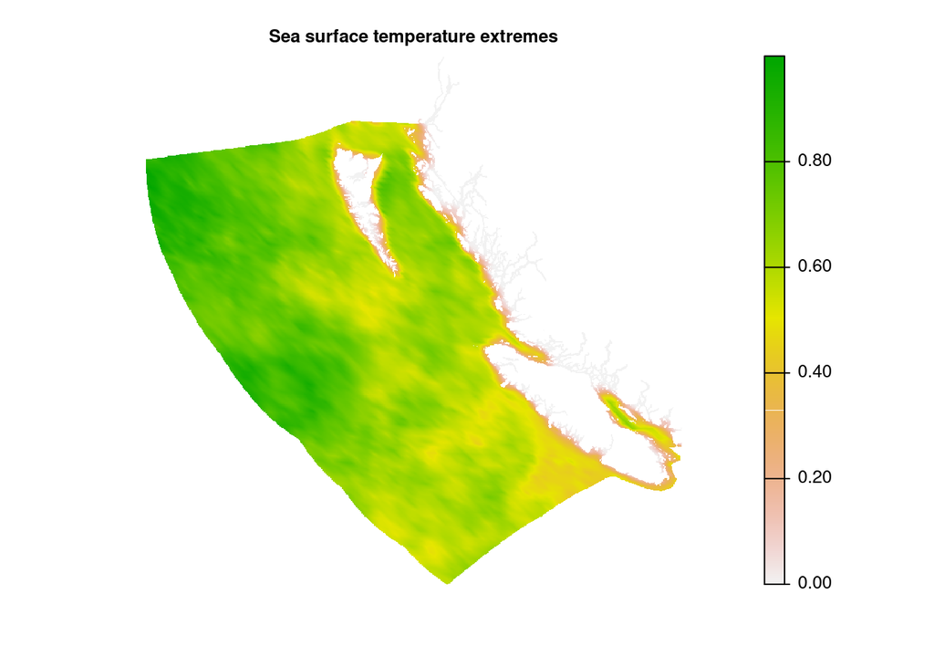

```r
extreme_sst_r <- rast(x_sst_local_f)

extreme_sst_bc <- project(extreme_sst_r, ocean_rast) %>%
  mask(ocean_rast) %>%
  rescale_stressor()

### round values to reduce file size
extreme_sst_bc <- round(extreme_sst_bc, 4)

writeRaster(extreme_sst_bc, here('_data/stressors_bc/sst_extremes_2020.tif'),
            overwrite = TRUE)

plot(extreme_sst_bc, axes = FALSE,
     main = 'Sea surface temperature extremes')
```

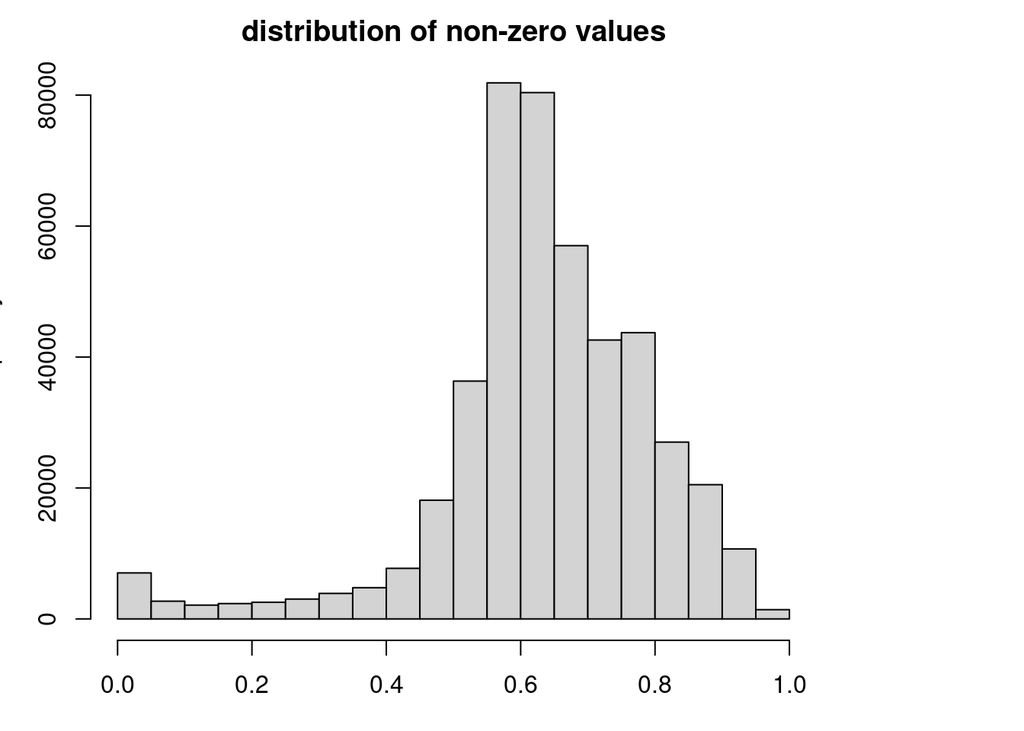

```r
hist(extreme_sst_bc[extreme_sst_bc > 0], main = 'distribution of non-zero values')
```

### 3.3.2 Sea level rise from OHI 2021

- Use annual mean SLR anomaly rasters from here:
  - dir: `git-annex/globalprep/prs_slr/v2021/int/msla_annual_mean/`
    - files: `msla_annual_2015.tif` to `msla_annual_2019.tif`
  - These are pre-transform and mask. Transformed and masked are also available, but let’s use these so we can make sure the transform and mask are accurate to our particular CRS.
- See OHI processing script for details: `https://github.com/OHI-Science/ohiprep_v2021/blob/gh-pages/globalprep/prs_slr/v2021/slr_layer_prep_v2.Rmd`

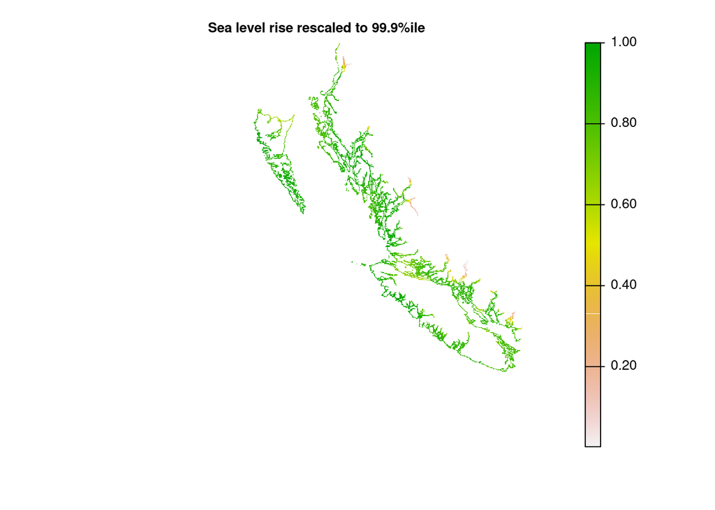

```r
slr_f <- here('_data/stressors_bc/sea_level_rise_2019.tif')
### unlink(slr_f)

if(!file.exists(slr_f)) {
  years <- 2015:2019
  local_fs <- here_anx('stressors/slr', sprintf('msla_annual_%s.tif', years))
  if(any(!file.exists(local_fs))) {
    orig_fs <- here_ohi('git-annex/globalprep/prs_slr/v2021/int/msla_annual_mean/',
                        sprintf('msla_annual_%s.tif', years))
    file.copy(orig_fs, local_fs)
  }
  raw_stack <- rast(local_fs)

  raw_r <- mean(raw_stack)
  # class       : SpatRaster
  # dimensions  : 720, 1440, 1  (nrow, ncol, nlyr)
  # resolution  : 0.25, 0.25  (x, y)
  # extent      : -180, 180, -90, 90  (xmin, xmax, ymin, ymax)
  # coord. ref. : lon/lat WGS 84 (EPSG:4326)
  # source(s)   : memory
  # name        :      mean
  # min value   : -1.043463
  # max value   :  0.503400
  ### In WGS84, .25 degree.
  ### First, use focal interpolation of mean of neighboring cells within
  ### a degree (inverse distance weighting) to help make raw SLR layer
  ### extends all the way to coastline.
  focal_rad <- 4
  focal_dia <- focal_rad*2+1
  focal_mtx <- matrix(nrow = focal_dia, ncol = focal_dia)
  for(i in 1:focal_dia) {
    for(j in 1:focal_dia) {
      ### i <- 1; j <- 1
      d <- sqrt((i - (focal_rad + 1))^2 + (j - (focal_rad + 1))^2)
      focal_mtx[i, j] <- 1 / d
    }
    focal_mtx[focal_rad + 1, focal_rad + 1] <- 1
  }
  ### NOTE: [focal] with "na.rm=TRUE" and weights other than 0, 1, or NA, only fun="sum" is allowed
  ### so: use sum, then divide by the sum of the weights:
  gf_r <- focal(raw_r, focal_mtx,
                fun = sum, na.rm = TRUE)
  gf_r <- gf_r / sum(focal_mtx)

  ### replace NA cells in the original with their counterparts in gf_r_only
  combo <- raw_r
  values(combo)[is.na(values(combo))] <- values(gf_r)[is.na(values(combo))]

  ### Project to bc 1km and masking to coastal 1 km cells
  slr_bc_r <- project(combo, ocean_rast)
  coastal_r  <- rast(here('_spatial/coastal_1km_buffer_bc_1km.tif'))

  slr_coastal_r <- mask(slr_bc_r, coastal_r)

  # missing <- coastal_r
  # values(missing)[!is.na(values(slr_coastal_r))] <- NA
  # plot(missing, col = 'red')
  # ### still 4161 coastal cells missing values - bc regions

  ### Set negative values to zero, then rescale
  values(slr_coastal_r)[values(slr_coastal_r) < 0] <- 0
  slr_coastal_r <- slr_coastal_r %>%
    rescale_stressor(qtile = .999)

  ### round to drop ludicrous precision then save out
  values(slr_coastal_r) <- round(values(slr_coastal_r), 5)
  writeRaster(slr_coastal_r, slr_f, overwrite = TRUE)

  ### to identify post-mask gapfilled cells
  # gf_map_wgs84 <- mask(gf_r, orig_r, inverse = TRUE)
  # gf_map_moll <- projectRaster(gf_map_wgs84, ocean_rast)
  # gf_map_moll_mask <- mask(gf_map_moll, coastal_r, inverse = FALSE)
  # plot(gf_map_moll_mask, col = 'red')

}

r <- rast(slr_f)

plot(r, axes = FALSE,
     main = 'Sea level rise rescaled to 99.9%ile')
```

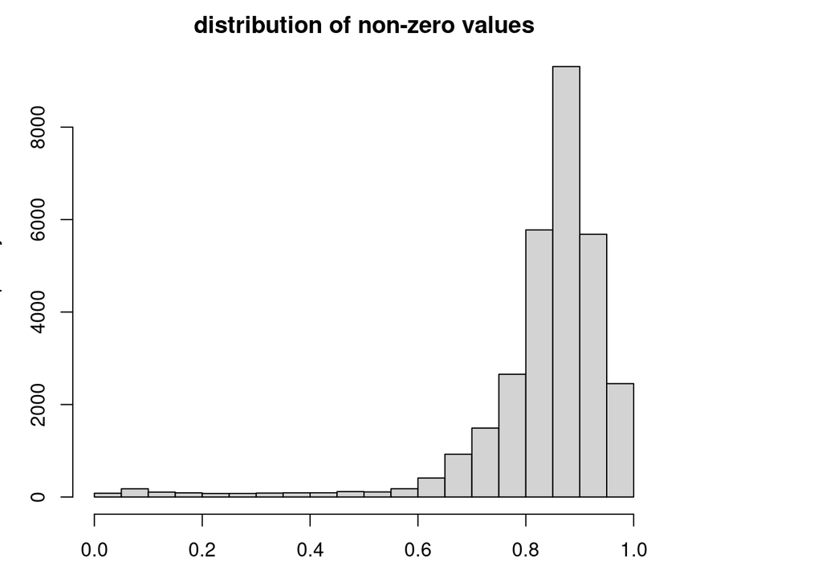

```r
hist(r[r > 0], main = 'distribution of non-zero values')
```

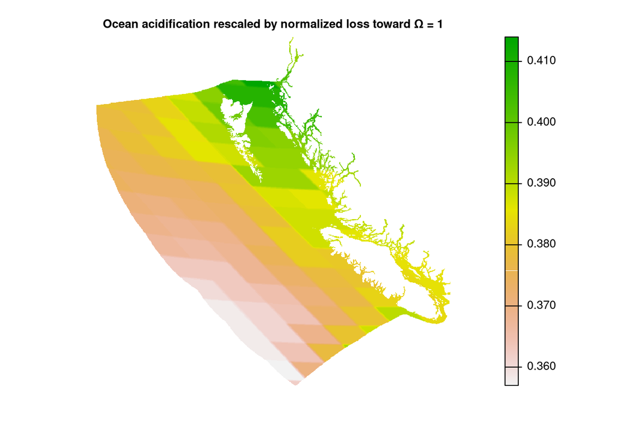

```r
oa_f <- here('_data/stressors_bc/ocean_acidification_2020.tif')
### unlink(oa_f)

if(!file.exists(oa_f)) {

  oa_resc_mol_local_f <- here_anx('stressors/oa', 'oa_resc_int_2020.tif')
  if(!file.exists(oa_resc_mol_local_f)) {
    oa_resc_mol_f <- here_ohi('git-annex/globalprep/prs_oa/v2017/int',
                         'annual_avg_moll_rescaled_int',
                         'oa_resc_int_2020.tif')
    file.copy(oa_resc_mol_f, oa_resc_mol_local_f)
  }
  raw_r <- rast(oa_resc_mol_local_f)
  # class       : SpatRaster
  # dimensions  : 341, 332, 1  (nrow, ncol, nlyr)
  # resolution  : 112000, 54700  (x, y)
  # extent      : -18597502, 18586498, -9085652, 9567048  (xmin, xmax, ymin, ymax)
  # coord. ref. : Mollweide
  # source      : oa_resc_int_2020.tif
  # name        : oa_resc_int_2020
  # min value   :                0
  # max value   :                1

  ### project to bc 1 km
  disagg_r <- disagg(raw_r, fact = 10)
  oa_r <- project(disagg_r, ocean_rast)

  oa_masked <- mask(oa_r, ocean_rast)

  ### round to drop ludicrous precision then save out
  values(oa_masked) <- round(values(oa_masked), 3)
  writeRaster(oa_masked, oa_f, overwrite = TRUE)

}

r <- rast(oa_f)

plot(r, axes = FALSE,
     main = 'Ocean acidification rescaled by normalized loss toward Ω = 1')
```

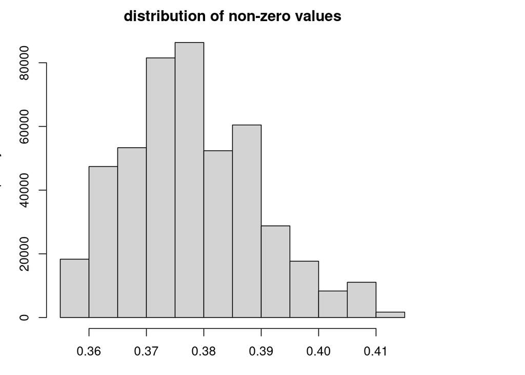

```r
hist(r[r > 0], main = 'distribution of non-zero values')
```

### 3.3.4 Ultraviolet radiation from OHI 2021

- dir: `git-annex/globalprep/prs_uv/v2021/int/rescaled/`
  - file: `annual_diff_2016_2020_rescaled.tif`

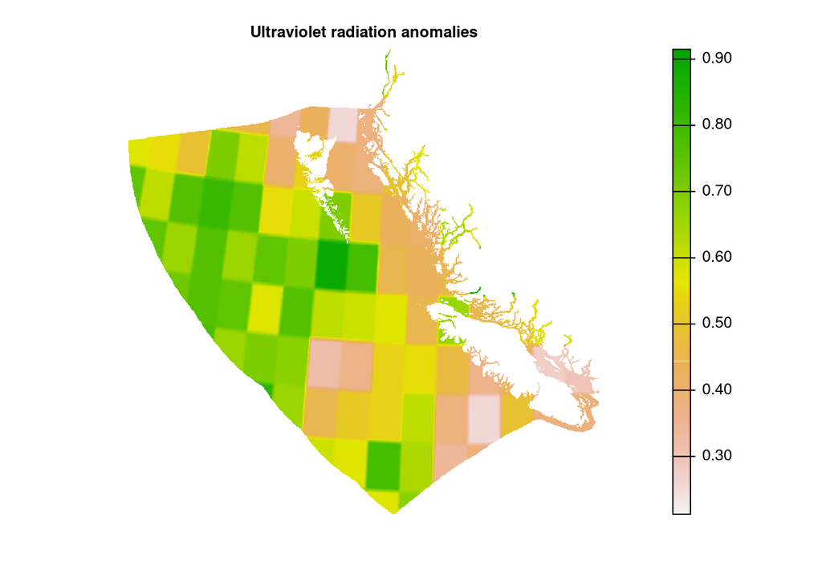

```r
uv_f <- here('_data/stressors_bc/uv_radiation_2020.tif')
### unlink(uv_f)

if(!file.exists(uv_f)) {
  local_f <- here_anx('stressors/uv', 'annual_diff_2016_2020_rescaled.tif')
  if(!file.exists(local_f)) {
    orig_f <- here_ohi('git-annex/globalprep/prs_uv/v2021/int/rescaled',
                       'annual_diff_2016_2020_rescaled.tif')
    file.copy(orig_f, local_f)
  }
  raw_r <- rast(local_f)
  # class       : SpatRaster
  # dimensions  : 180, 360, 1  (nrow, ncol, nlyr)
  # resolution  : 1, 1  (x, y)
  # extent      : -180, 180, -90, 90  (xmin, xmax, ymin, ymax)
  # coord. ref. : lon/lat WGS 84 (EPSG:4326)
  # source      : annual_diff_2016_2020_rescaled.tif
  # name        : annual_diff_2016_2020_rescaled
  # min value   :                              0
  # max value   :                              1
  ### disaggregate to be closer to 1 km res
  disagg_r <- raw_r %>%
    disagg(fact = 10)

  uv_r <- project(disagg_r, ocean_rast)


  uv_r <- mask(uv_r, ocean_rast)

  ### round to drop ludicrous precision then save out
  values(uv_r) <- round(values(uv_r), 5)
  writeRaster(uv_r, uv_f, overwrite = TRUE)
}

r <- rast(uv_f)

plot(r, axes = FALSE,
     main = 'Ultraviolet radiation anomalies')
```

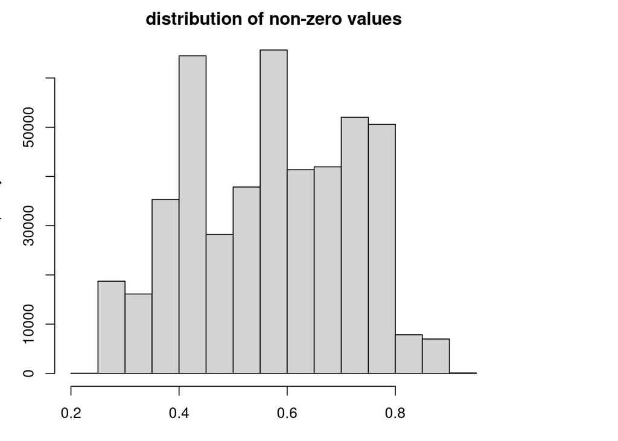

```r
hist(r[r > 0], main = 'distribution of non-zero values')
```

## 3.4 Ocean-based stressors

## 3.5 Sensory stressors

### 3.5.1 Light pollution

Per the suggestion by the authors, we will clip out any values below a threshold (7? 20?) as being prone to fluctuation and therefore potentially not stable.

> The VIIRS-derived results are more fluctuated during the period from 2015 to 2018 for pixels with DN values greater than 7 (Fig. 5a,b), and this fluctuation was notably mitigated for pixels with relatively high DNs. This suggests the converted DN values from VIIRS data are more reliable for pixels with DN values larger than 20 (Fig. 5c,d), and the derived temporal patterns of SNTL and lit pixels are more reliable for pixels with DN values above 30 (Fig. 5e,f). There are two possible reasons for the fluctuation of derived NTL time series data from VIIRS. First, the original observations of VIIRS NTL data fluctuate over years24. For example, the drop of SNTL and lit pixels from 2015 to 2016 in our result was also observed in the annual result of VIIRS data from the Payne Institute for Public Policy under the Colorado School of Mines24. Second, the simulated DMSP-like NTL data from VIIRS have a larger extent than the DMSP data with the improved sensitivity of sensors in VIIRS and the aggregation procedure using the kernel density method and point-spread function, especially in low luminance regions (Fig. S3). After excluding those low luminance regions using the threshold of 7, the derived NTL result from VIIRS is closer with the DMSP data. When the threshold increases to 20 and 30, most blooming effects around the city and villages are eliminated, resulting in a more continuous time series data of the SNTL and the number of lit pixels (Fig. 5)

Note that with a threshold of 7 there appear to be artifacts in the 2018 data in the bc and in the waters south of Australia. Could this be legit light pollution, or auroras? Try using the minimum value for each cell between the 2017 and 2018 rasters, then dropping values below 10.

Also, examine the ocean-based sources of stable light as potential benthic structures?

- dir: `/home/shares/ohi/spp_vuln/spp_vuln_mapping/stressors/light`
  - file: `Harmonized_DN_NTL_2018_simVIIRS.tif`

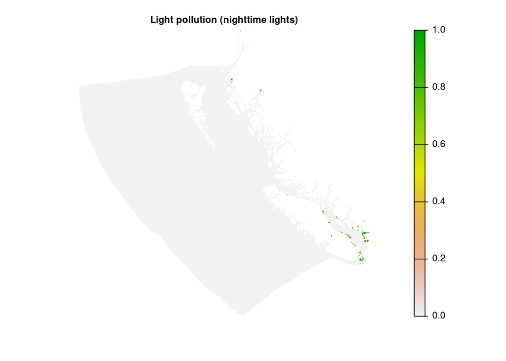

```r
light_f <- here('_data/stressors_bc/light_2018.tif')
### unlink(light_f)

if(!file.exists(light_f)) {
  light_fs <- list.files(here_anx('../spp_vuln_mapping/stressors/light'),
                         full.names = TRUE)
  light_stack <- rast(light_fs)
  # class       : SpatRaster
  # dimensions  : 16801, 43201, 2  (nrow, ncol, nlyr)
  # resolution  : 0.008333333, 0.008333333  (x, y)
  # extent      : -180.0042, 180.0042, -65.00417, 75.00417  (xmin, xmax, ymin, ymax)
  # coord. ref. : lon/lat WGS 84 (EPSG:4326)
  # sources     : Harmonized_DN_NTL_2017_simVIIRS.tif
  #               Harmonized_DN_NTL_2018_simVIIRS.tif
  # names       : Harmonized_DN_NTL_2017_simVIIRS, Harmonized_DN_NTL_2018_simVIIRS
  # min values  :                               0,                               0
  # max values  :                              63,                              63
  ### take min of 2017 and 2018 to help drop artifacts
  min_light_r <- min(light_stack)

  ### For global, we cropped north/south slightly to remove artifacts;
  ### how to deal with aurora type artifacts?  Perhaps crop to near-shore,
  ### though this may eliminate certain fishing and offshore activity...

  thresh <- 10
  values(min_light_r)[values(min_light_r) < thresh] <- 0

  light_r_bc <- project(min_light_r, ocean_rast)

  ### make a land raster with a 3 nmi buffer
  land_rast <- ocean_rast
  values(land_rast) <- 1
  land_rast <- mask(land_rast, ocean_rast, inverse = TRUE)
  buffer_3nmi <- rast(here('_spatial/coastal_3nmi_buffer_bc_1km.tif'))
  values(land_rast)[!is.na(values(buffer_3nmi))] <- 1

  ### mask light pollution to land and 3nmi buffer
  light_bc_masked <- light_r_bc %>%
    mask(land_rast)
  ### fill NA cells with zero
  values(light_bc_masked)[is.na(values(light_bc_masked))] <- 0
  light_bc_rescaled <- mask(light_bc_masked, ocean_rast) %>%
    rescale_stressor(qtile = .999)

  ### round to drop ludicrous precision then save out
  values(light_bc_rescaled) <- round(values(light_bc_rescaled), 5)
  writeRaster(light_bc_rescaled, light_f, overwrite = TRUE)
}

r <- rast(light_f)

plot(r, axes = FALSE,
     main = 'Light pollution (nighttime lights)')
```

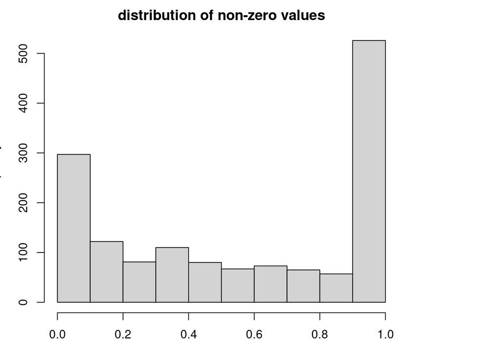

```r
hist(r[r > 0], main = 'distribution of non-zero values')
```